# Yes, it Really is Cold in the UK

## Introduction

My friend not only had a poor lapse in judgement in wanting to move the UK, but she is also convinced that the weather in the mid-parts of the UK, where she intends to reside, is mostly sunny, and not rainy or cold at all. This report is aims to convince her that the weather where she is moving is terribly cold, and uses statistics and figures to do so.

## Analysis

The figure below summarises the average temperatures (in degrees Celsius) for the mid part of the UK for every season over the last 50 years.

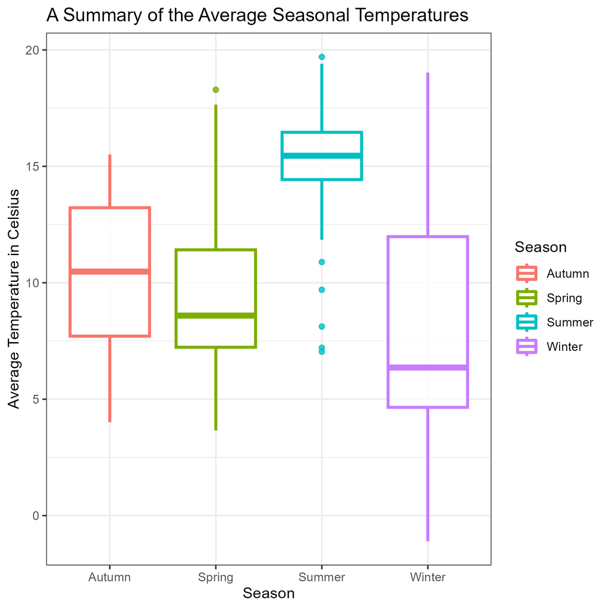

If this is not convincing, the figure below shows the weather for 2022. It clearly shows that most days last year were either cold or SUPER cold, with only a few days being hot. But, luckily, if my friend does decide to move to the UK, she will only experience a few disgustingly cold days.

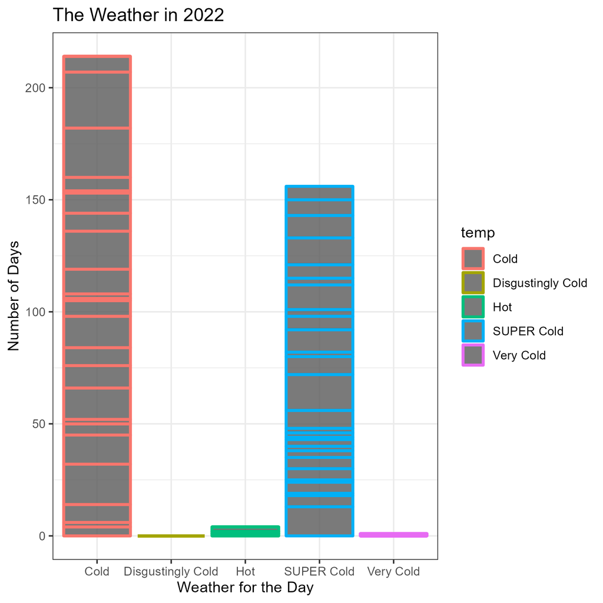

## Conclusion

The mid-parts of the UK are at best chilly all year round, with only a few hot days occuring in the year. The summer season is rarely warmer than 18 degrees Celsius, which makes it comparable to a South African winter. Most days in the mid regions of the UK are either cold or SUPER cold.